# Risky New York: Gendered Spatial Practices Between the Gay City and the Normative City, 1965-1996

Lucas Avelar

April 29, 2023

The study of historically marginalized groups and their presence in, movement through, and production of space must be conceived in consideration of the multiple ways through which those groups, in historian George Chauncey’s words, sought “to claim space for themselves in the midst of a hostile society” on an everyday basis.[^1] Gay men, in particular, built an entire subculture – that means, one that developed in relation to another culture’s parameters, expectations, and norms – that was extensive, visible, and sophisticated during the first third of the twentieth century. Scholarship on the queer culture and life before the landmark of Stonewall, however, often assumed the premise of internalization, invisibility, and isolation as a given fact. As Chauncey has demonstrated, the “gay world” was much more tolerated, integrated, and more importantly, visible to outsiders in the pre-war years than it came to be in the second third of the century.

Early-twentieth-century gay men did not passively internalize and accept the dominant cultural perspective on their sexuality and identities, nor were they invisible figures in thriving urban landscapes like New York, Minneapolis, and Boston. The shift started in the 1930s and it was all but immediate. New waves of anti-gay policing and legislation forced gay people to gradually hide their complex social network from the eyes of outsiders. Arrest numbers of gay men in New York City during the 1930s for engaging with gay life in the public sphere skyrocketed. Gradually yet violently, the gay city was suppressed back into the shadows of the normative city. But as Chauncey insists, despite the forceful discretion and increased state censorship and control over homosexual life over the 1940s and 1950s, the gay world “continued to thrive and became even more extensive.”[^2]

In this short article, by using methodologies of data exploratory analysis to examine the available data from the *Mapping the Gay Guides* project, I contend that the suppressed gay landscape in New York City thrived, among other things, as a result of non-conforming spatial practices and appropriation of public spaces of the normative city by gay men. In the public sphere, danger and risk factored on how particular locales became associated with gay culture and resistance to *status quo*. The Gay New York City in the second half of the twentieth century was a stubborn response to Risky New York - a heteronormative cultural topography and sexual regime established during and after the Second World War.

### A Shared Sense of Place

Scholarly interest and inquiry in queer life became a risky endeavor, and looking for spaces where gay culture thrived in American urban centers was considered potentially dangerous for one’s professional and academic reputation.

Since the cultural turn in historical scholarship in the 1980s, scholars like Judith Walkowitz, John D’Emilio, Estelle B. Freedman, and Linda Gordon began to challenge the notion of sexuality and its role in shaping gender as a social construct. Feminist scholarship pushed for a new understanding of sex and gender identity as manifestations of complex power dynamics and hierarchic structures of culture in society.[^3] In 1988, Freedman and D’Emilio published their *Intimate Matters: A History of Sexuality in America*, in which they demonstrated how, over the course of the nineteenth century, the American sexual experience and their very notion of sexuality became less and less associated with reproduction. Ultimately, the emerging notion of sexuality centered around family and intimacy reinforced the “separate sexual spheres” and separate work spaces of men and women: the domestic and the public realms.[^4]

Not surprisingly, and maybe as a result of reinforced state vigilance and control over sexuality and gender norms after the war,both gay men and women found ways to take control over public spaces in large urban areas to exist, express, and experience their sexual and gender identities. Those spaces did not originally identify as gay spaces, and despite the repressive spatial and social organization of the normative city, gay men appropriated those locations and re-signified their value and role in the now-hidden and suppressed gay city. This city, in contrast to the normative city, was constituted of an array of businesses, organizations, institutions, and cruising areas that enabled resisting forms of spatial practice based on an ever-growing sense of identity and sense of place.[^5]

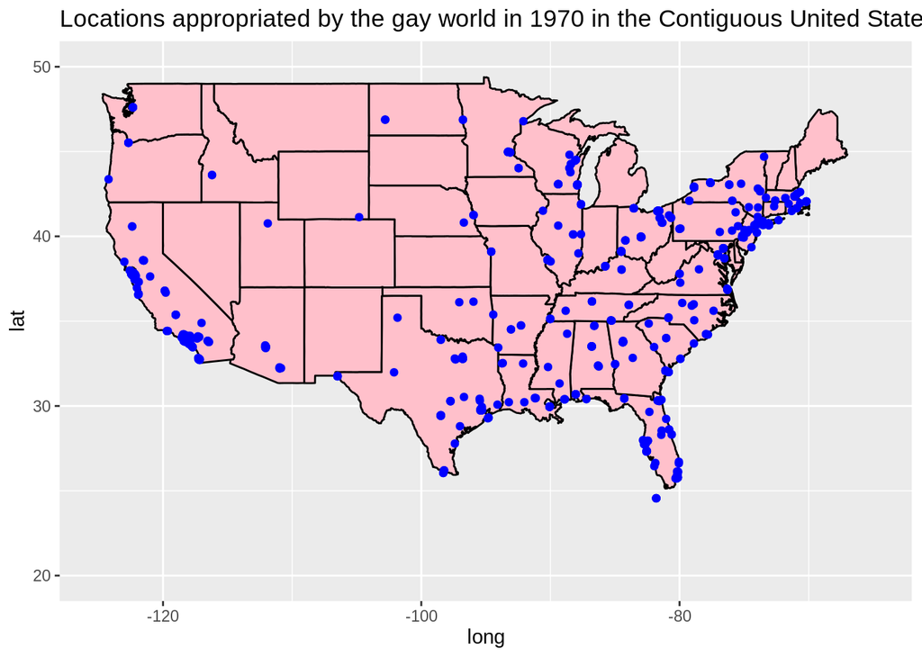

```r
usamap <- map_data("state")
gayguides.complete <- read.csv("~/Risky-New-York/gay guides data/gayguides.complete.csv")

#filter gayguides.complete data to 1965-1970
#filter out US territories from visualization
vis.gg.1970 <- gayguides.complete %>%
filter(state != 'VI' & state != 'PR' & state != 'GU' & state != 'HI') %>%
filter(Year == 1970)

ggplot() +
  geom_map(data = usamap, map = usamap, aes(long, lat, map_id=region), fill = "pink", linewidth = 0.5, colour = "black") +
  geom_point(data = vis.gg.1970, mapping = aes(x=lon, y=lat), colour = "blue") + labs(title = "Locations appropriated by the gay world in 1970 in the Contiguous United States") +
  xlim(-125, -65) +
  ylim(20, 50)
```

Damron’s Address Books incorporated multiple signals for categorizing gay locations according to social function, sociability, safety, and popularity. The “Explanation of Listings” page – which became the “Key to Listing Codes” page in 1990 – provided readers with descriptive categories that indicated the types of locations and which groups frequented each place. Some categories like “HOT” and “AYOR” (At Your Own Risk) also denoted danger, policing, frequent arrests, or risk of violent encounters with non-queer groups. Over the years, the risk factor varied according to larger social and political trends related to gay life and culture.

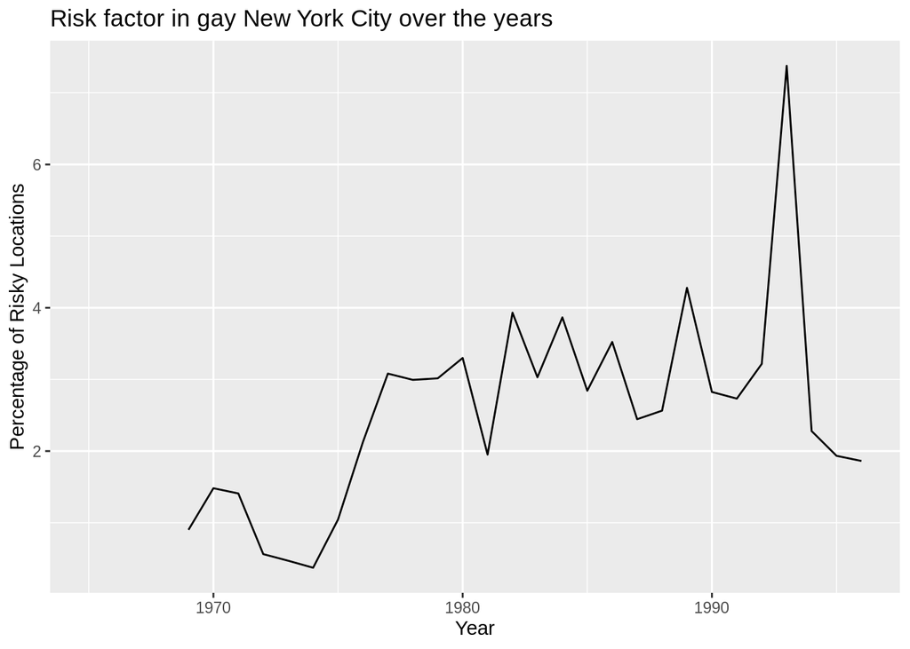

```r
risky.newyork.count <- read.csv("~/Risky-New-York/gay guides data/risky.newyork.count.csv")

risky.newyork.count %>%
  ggplot(aes(x = Year, y = relative.risk)) +
  geom_line() + labs(title = 'Risk factor in gay New York City over the years', x = 'Year', y = 'Percentage of Risky Locations')
```

```r
#subset gaynewyork to visualize the different categorizations of the Ramrod Bar over time
gayguides.complete <- read.csv("~/Risky-New-York/gay guides data/gayguides.complete.csv")
#subset data to NY locations only
gaynewyork <- gayguides.complete %>%
  filter(state == "NY")

ramrod.vis <- gaynewyork %>%
  filter(grepl('394 West', streetaddress)) %>%
  select(description, Year, amenityfeatures) %>%
  na.exclude()

ramrod.vis <- ramrod.vis[, c(2, 3, 1)]

ramrod.vis <- ramrod.vis %>%
  select(Year, amenityfeatures, description) %>%
  group_by(Year)

ramrod.vis %>%
  arrange(Year)
```

```
## # A tibble: 10 × 3
## # Groups:   Year [9]
##     Year amenityfeatures      description
##    <int> <chr>                <chr>
##  1  1974 "(W),(SM)"           "(open afternoons) at 10th St."
##  2  1974 ""                   ""
##  3  1975 "(YC),(W),(SM)"      "(Some SM) (open afternoons) at 10th St."
##  4  1976 "(YC),(W),(SM),(*)"  "(some W, SM) Pleasure Chest at 10th St."
##  5  1977 "(YC),(W),(SM),(*)"  "(Sunday brunch) at 10th Street"
##  6  1979 "(*),(W),(SM),(FFA)" "(Some W, SM, FFA) (Best cruise bar on Dock Strip…
##  7  1980 "(*),(W),(SM),(FFA)" "(Some W, SM, FFA) (Best cruise bar on Dock Strip…
##  8  1981 "(*),(W),(SM),(FFA)" "(Some W, SM, FFA)(Best cruise bar on Dock Strip)…
##  9  1982 "(*),(W),(SM)"       "(Some W, SM, FFA) (Tragic shooting)"
## 10  1983 "(*),(W),(SM),(FFA)" "(Some W, SM, FFA) betw. Christopher"
```

#### Step 1: Read the data and formulate the question

If the user filtered the map to show only locations that existed in the state of New York in 1980, for example, this is how it would look like:

```r
gayguides.complete <- read.csv("~/Risky-New-York/gay guides data/gayguides.complete.csv")

gg.nyc.1980 <- gayguides.complete %>%
  filter(state == "NY" & Year == 1980)

leaflet(data=gg.nyc.1980) %>% addTiles() %>% addMarkers(~lon, ~lat, popup = paste("Location Name:", gg.nyc.1980$title, ", ", "Type:", gg.nyc.1980$type))
```

[interactive chart not shown]

[^1]: George Chauncey, *Gay New York: Gender, Urban Culture, and the Making of the Gay Male World* (New York: Basic Books, 1994), 5.
[^2]: George Chauncey, *Gay New York*, 9.
[^3]: Judith Walkowitz, *Prostitution and Victorian Society: Women ,Class, and the State* (Cambridge: Cambridge University Press, 1980); Jonh D’Emilio, *Sexual Politics, Sexual Communities: The Making of a Homosexual Minority in the United States, 1940-1970* (Chicago: University of Chicago Press, 1983); Estelle B. Freedman, “Sexuality in Nineteenth-Century America: Behavior, Ideology and Politics,” *Reviews in American History* 10 (December 1982): 196-215; Linda Gordon, *Woman’s Body, Woman’s Right: A Social History of Birth Control in America* (New York: Grossman, 1976).
[^4]: John D’Emilio and Estelle B. Freedman, *Intimate Matters: A History of Sexuality in America* (Chicago: Chicago University Press, 1988), 57-59.
[^5]: John Brinckerhoff Jackson has discussed how our sense of place is intimately connected to our sense of shared time. Here, I use the notions of sense of place and sense of time to suggest that the thriving gay city (or, the gay world of appropriated places) was built on shared rituals and, as per Jackson, a shared “timetable:” Because gay men ritually returned to those same spaces in the city, they established a sense of place in those locations that solidified their belonging to a larger gay community and culture. See: John Brinckerhoff Jackson, *A Sense of Place, A Sense of Time* (Yale University Press, 1994), 157-160.
[^6]: David K. Johnson, *Buying Gay: How Physique Entrepreneurs Sparked a Movement* (New York: Columbia University Press, 2019), 193.
[^7]: Thomas L. Long, *AIDS and American apocalypticism: the cultural semiotics of an epidemic* (Albany: State University of New York Press, 2005), 108-109.
[^8]: For a recent example, see Larry Knopp and Michael Brown, “Travel Guides, Urban Spatial Imaginaries and LGBTQ+ activism: The case of Damron Guides,” *Urban Studies* (February 2020): 1-17.